# Do Standard Vector Reprojection Workflows in GIS Preserve Topological Relations?

Xuezhi Cang xuezhicang@gmail.com

When I first learned about map projections in a GIS 101 class nearly 20 years ago, I was told that map projections preserve topology. Looking back now, I realize this was likely a miscommunication among mathematicians, cartographers, and students. The statement is not entirely accurate, especially in high-resolution or global-scale research contexts.

I recently asked ChatGPT about this question, and the response is shown below. ChatGPT suggested that map projections do not change topology, but only alter geometric properties.

See the response of ChatGPT

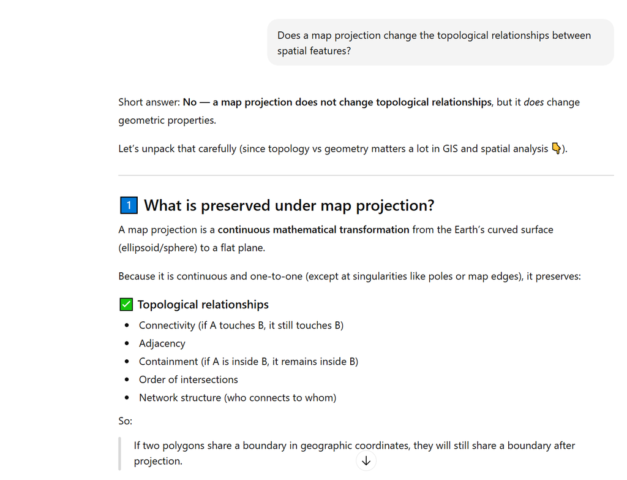

Am I satisfied with this answer?

Short answer: No. ChatGPT’s response reflects a classic textbook perspective intended for beginners, and it contains some inaccuracies. If we examine the question more carefully and think about it more deeply, the answer can be far more nuanced and sophisticated.

In mathematics, a projection that is continuous and one-to-one preserves topological structure within its domain.

At first glance, we might assume that most map projections satisfy this condition. However, in practice, none of them do because spatial vector data are not truly continuous. Instead, they are discrete representations of space. As a result, the mathematical conditions required for strict topological invariance are not met in real-world mapping workflows.

## Mapping a line and a point on it under the Mercator projection (EPSG: 3857)

Let me present a few figures to illustrate why I argue that map projections, within a standard GIS workflow, cannot fully preserve the topological relationships among spatial features.

Figure 1 shows a line and a point located on that line in the Los Angeles, CA area under the Mercator projection.

I also calculated the distance between the line and the point, which is 0 (as expected).

```
Distance (meters) between line and point: 0.000
```

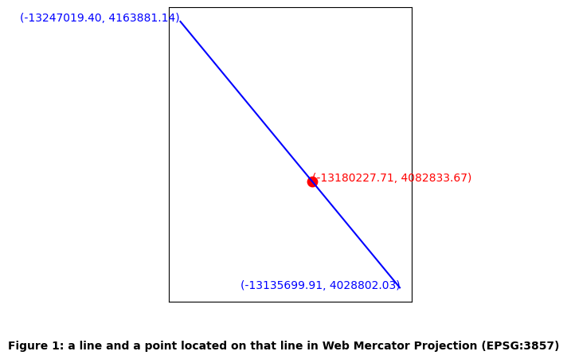

```python
import geopandas as gpd
from shapely.geometry import LineString
import matplotlib.pyplot as plt
import random
from shapely.geometry import LineString, Polygon,Point

# Define line in lat/lon
line = LineString([(-118, 34), (-119, 35)])

r = 0.4 #random.random()
gdf_line_merc = gpd.GeoDataFrame({"geometry": [line]}, crs="EPSG:4326").to_crs(epsg=3857) # project the line to WGS 84 / Web Mercator

mid_pt = gdf_line_merc.geometry.iloc[0].interpolate(r, normalized=True) # get a point on the gdf_line
gdf_point_merc = gpd.GeoDataFrame({"geometry": [mid_pt]}, crs=gdf_line_merc.crs)

# calculate distance between gdf_line and gdf_point
distance_m = gdf_point_merc.geometry.iloc[0].distance(
    gdf_line_merc.geometry.iloc[0]
)

print(f"Distance (meters) between line and point: {distance_m:.3f}")

# Plot directly
fig, ax = plt.subplots()
gdf_line_merc.plot(ax=ax, color="blue")
gdf_point_merc.plot(ax=ax, color="red", markersize=80)

# ----------------------------
# Label vertex coordinates
# ----------------------------
for (x, y) in  gdf_line_merc.geometry.iloc[0].coords:
    ax.text(x, y,f"({x:.2f}, {y:.2f})",fontsize=10,ha="right", color="blue"    )

# ----------------------------
# Label point coordinate
# ----------------------------
ax.text(gdf_point_merc.geometry.iloc[0].x, gdf_point_merc.geometry.iloc[0].y,    f"({gdf_point_merc.geometry.iloc[0].x:.2f}, {gdf_point_merc.geometry.iloc[0].y:.2f})",    fontsize=10,    ha="left",    color="red")


ax.set_xticks([])
ax.set_yticks([])

plt.suptitle(
    "Figure 1: a line and a point located on that line in Web Mercator Projection (EPSG:3857)",
    fontsize=10,
    fontweight="bold",
    y=0.01
)
plt.show()
```

## Reprojecting the line and the point to the World Sinusoidal projection (ESRI:54008)

I reprojected both the line and the point into the World Sinusoidal projection and recalculated the distance between them. This time, the point shifted slightly and is no longer exactly on the line. As a result, the distance between the line and the point is no longer zero.

```
Distance (meters) between line and point:  500.58527766891143
```

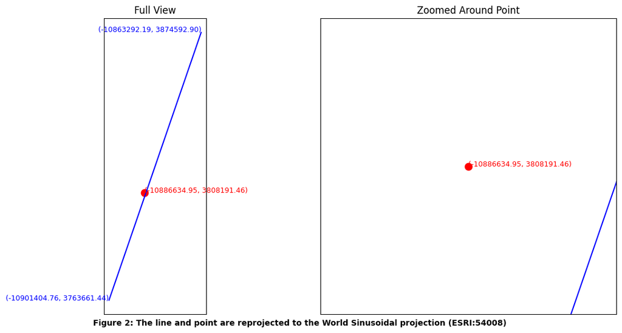

```python
gdf_line_sinu = gdf_line_merc.to_crs("ESRI:54008") # project line to World Sinusoidal projection
gdf_point_sinu = gdf_point_merc.to_crs("ESRI:54008") # project point to World Sinusoidal projection

distance_m = gdf_point_sinu.geometry.iloc[0].distance(
    gdf_line_sinu.geometry.iloc[0]
)

print("Distance (meters) between line and point: ", distance_m)

# Create figure with two panels
fig, (ax1, ax2) = plt.subplots(1, 2, figsize=(12, 6))

# ----------------------------
# Full view
# ----------------------------
gdf_line_sinu.plot(ax=ax1, color="blue")
gdf_point_sinu.plot(ax=ax1, color="red", markersize=80)

ax1.set_title("Full View")
ax1.set_xticks([])
ax1.set_yticks([])

# Add coordinate labels to Full View only
for (x, y) in gdf_line_sinu.geometry.iloc[0].coords:
    ax1.text(x, y,f"({x:.2f}, {y:.2f})",fontsize=9,ha="right",color="blue"    )

ax1.text( gdf_point_sinu.geometry.iloc[0].x, gdf_point_sinu.geometry.iloc[0].y, f"({gdf_point_sinu.geometry.iloc[0].x:.2f}, {gdf_point_sinu.geometry.iloc[0].y:.2f})",
    fontsize=9,    ha="left",    color="red")

ax2.text( gdf_point_sinu.geometry.iloc[0].x, gdf_point_sinu.geometry.iloc[0].y,    f"({gdf_point_sinu.geometry.iloc[0].x:.2f}, {gdf_point_sinu.geometry.iloc[0].y:.2f})",
    fontsize=9,    ha="left",    color="red")


# ----------------------------
# Zoomed view around point
# ----------------------------
gdf_line_sinu.plot(ax=ax2, color="blue")
gdf_point_sinu.plot(ax=ax2, color="red", markersize=80)

# Get point coordinates
px = gdf_point_sinu.geometry.iloc[0].x
py = gdf_point_sinu.geometry.iloc[0].y

# Define zoom window (adjust buffer as needed)
buffer = distance_m +10  # meters (change as needed)

ax2.set_xlim(px - buffer, px + buffer)
ax2.set_ylim(py - buffer, py + buffer)


ax2.set_title("Zoomed Around Point")
ax2.set_xticks([])
ax2.set_yticks([])


plt.suptitle(
    "Figure 2: The line and point are reprojected to the World Sinusoidal projection (ESRI:54008)",
    fontsize=10,
    fontweight="bold",
    y=0.01
)


plt.tight_layout()
plt.show()
```

Wow! Comparing Figure 1 and Figure 2, the result is quite interesting. After reprojection, the point is no longer located on the line. This occurs because the map projection transforms only the vertices of the line to new coordinates and then reconnects them as a straight segment in the target projection.

A line that appears straight in geographic coordinates (or in one projection) does not necessarily remain straight after being projected into another coordinate system. In many cases, a straight line in Mercator space may become curved in a different projection.

## An example involving a point and a polygon

Here is another example. A map projection alters the topological relationship between a point and a polygon, transforming a point that originally lies on (or within) the polygon into one that falls outside it. This issue is more severe because it does not merely modify geometric quantities (such as distance or area); it fundamentally changes topological relationships(spatial predicate).

As shown in Figure 3, the point is originally located on the boundary of the polygon under the Mercator projection. However, after reprojection to the World Sinusoidal projection, the point lies outside the polygon.

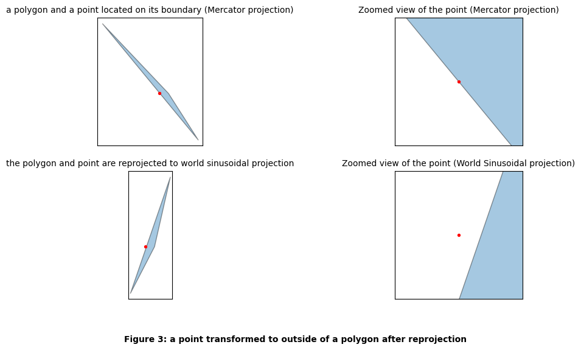

```
Mercator: Point inside polygon? True
Sinusoidal: Point inside polygon? False
```

```python
offset_pt = Point(mid_pt.x + 10000, mid_pt.y)  # create a point on the right side of the selected point
poly = Polygon(list(gdf_line_merc.geometry.iloc[0].coords) + list(offset_pt.coords)[::-1])

gdf_poly_merc = gpd.GeoDataFrame({"geometry": [poly]}, crs="EPSG:3857")
gdf_poly_sinu = gdf_poly_merc.to_crs("ESRI:54008") # project line to World Sinusoidal projection


# Create figure with two panels
fig, axes = plt.subplots(2, 2, figsize=(12, 6))




ax1 = axes[0, 0]
gdf_poly_merc.plot(ax=ax1, alpha=0.4, edgecolor="black")
gdf_point_merc.plot(ax=ax1, color="red", markersize=8)
ax1.set_title("a polygon and a point located on its boundary (Mercator projection)",fontsize=10)

ax2 = axes[0, 1]
buffer = distance_m +1000  # meters (change as needed) # Define zoom window (adjust buffer as needed)
px = gdf_point_merc.geometry.iloc[0].x
py = gdf_point_merc.geometry.iloc[0].y
ax2.set_xlim(px - buffer, px + buffer)
ax2.set_ylim(py - buffer, py + buffer)
gdf_poly_merc.plot(ax=ax2, alpha=0.4, edgecolor="black")
gdf_point_merc.plot(ax=ax2, color="red", markersize=8)
ax2.set_title("Zoomed view of the point (Mercator projection)",fontsize=10)


ax3 = axes[1, 0]
gdf_poly_sinu.plot(ax=ax3, alpha=0.4, edgecolor="black")
gdf_point_sinu.plot(ax=ax3, color="red", markersize=8)
ax3.set_title("the polygon and point are reprojected to world sinusoidal projection",fontsize=10)



ax4 = axes[1, 1]
buffer = distance_m +1000  # meters (change as needed)
px = gdf_point_sinu.geometry.iloc[0].x
py = gdf_point_sinu.geometry.iloc[0].y
ax4.set_xlim(px - buffer, px + buffer)
ax4.set_ylim(py - buffer, py + buffer)
gdf_poly_sinu.plot(ax=ax4, alpha=0.4, edgecolor="black")
gdf_point_sinu.plot(ax=ax4, color="red", markersize=8)
ax4.set_title("Zoomed view of the point (World Sinusoidal projection)",fontsize=10)



for ax in axes.flat:
    ax.set_xticks([])
    ax.set_yticks([])


plt.suptitle(
    "Figure 3: a point transformed to outside of a polygon after reprojection",
    fontsize=10,
    fontweight="bold",
    y=0.01
)

plt.show()



def check_inside(gdf_point, gdf_poly, label):
    point = gdf_point.geometry.iloc[0]
    polygon = gdf_poly.geometry.iloc[0]
    inside = point.within(polygon)
    print(f"{label}: Point inside polygon? {inside}")


check_inside(gdf_point_merc, gdf_poly_merc, "Mercator")
check_inside(gdf_point_sinu, gdf_poly_sinu, "Sinusoidal")
```

Following this logic, many other situations may arise: adjacent polylines may become separated, neighboring polygons may become disconnected, and similar topological inconsistencies can occur. For this reason, researchers should carefully examine their data when high-accuracy results are required after the reprojection.

## Solutions and summary

In my opinion, this issue has not attracted enough attention because most previous studies were conducted at a local scale or with relatively low resolution. As a result, the distortion of shapes caused by projection was minimal and often not noticeable.

However, with the development of global and high-resolution datasets, more problems are likely to emerge due to the issues discussed in this article.

Completely solving this problem is challenging. One common approach is to add additional vertices along lines before reprojection. In ArcGIS, this can be done automatically by enabling the Preserve Shape option (https://pro.arcgis.com/en/pro-app/latest/tool-reference/data-management/project.htm). In open-source tools such as GDAL and GeoPandas, the .segmentize() method (https://shapely.readthedocs.io/en/latest/reference/shapely.segmentize.html) can be used to densify geometries by adding vertices. However, the interval must be specified by the user, which is not always convenient.

Regardless of the method used, none of them can completely solve the problem, and densification inevitably increases the number of vertices. In big data analyses, this leads to a significant increase in computational burden.